# GEOG 490 Final Project

Roane Mullins

6/3/2019

## Sea Surface Temperature Mapping

This project maps the surface temperature of oceans around the world. The data comes from the NOAA Extended Reconstructed Sea Surface Temperature (ERSST v5) dataset. The project divides the world into a 2x2 degree grid, where each cell stores the temperature for a particular month. Completeness is accomplished using statistical methods. A more complete description of the project can be found [HERE](https://www.ncdc.noaa.gov/data-access/marineocean-data/extended-reconstructed-sea-surface-temperature-ersst-v5), and the source data files can be downloaded [HERE](https://www1.ncdc.noaa.gov/pub/data/cmb/ersst/v5/netcdf/).

The following code computes the minimum, maximum, and mean ocean sea surface temperature (SST) for 2018.

```r
# Load the packages
library(ncdf4)
library(lattice)
library(RColorBrewer)

# Setup the variables
# ncpath redacted for security
ncname_prefix <- "ersst.v5."
nc_year = "2018"
nc_name_extension = ".nc"
dname <- "sst"
nt <- 12

# Construct the surface temperature array array(nlon, nlat, nt)
for (x in sprintf("%02d", seq(1,nt))) {

  # Construct the filename
  ncfname <- paste(ncpath, ncname_prefix, nc_year, x, nc_name_extension, sep="")

  # Open the file
  ncin <- nc_open(ncfname)


  if (x == "01") {
    # Construct some globals the first time through the loop
    lon <- ncvar_get(ncin,"lon")
    lat <- ncvar_get(ncin,"lat")
    nlon <- dim(lon)
    nlat <- dim(lat)
    sst_array = array(dim=c(nlon, nlat, nt))
  }

  # get surface temperature for month
  sst_slice <- ncvar_get(ncin,dname)
  fillvalue <- ncatt_get(ncin,dname,"_FillValue")

  # replace netCDF fill values with NA's
  sst_slice[sst_slice==fillvalue$value] <- NA

  # save it to the global array
  sst_array[,,as.numeric(x)] = sst_slice

  # close file
  nc_close(ncin)
}

# prepare to compute the annual min, max, and mean
# reshape the array into vector
sst_vec_long <- as.vector(sst_array)

# reshape the vector into a matrix
sst_mat <- matrix(sst_vec_long, nrow=nlon*nlat, ncol=nt)

# create a dataframe
lonlat <- as.matrix(expand.grid(lon,lat))
sst_df <- data.frame(cbind(lonlat,sst_mat))


# get the annual mean and max and min
sst_df$max <- apply(sst_df[3:14],1,max) # max
sst_df$min <- apply(sst_df[3:14],1,min) # min
sst_df$mean <- apply(sst_df[3:14],1,mean) # annual (i.e. row) means

# convert the mean, max, min to arrays for plotting
sst_max_array <- array(sst_df$max, dim=c(nlon,nlat))
sst_min_array <- array(sst_df$min, dim=c(nlon,nlat))
sst_mean_array <- array(sst_df$mean, dim=c(nlon,nlat))

# plot the arrays
grid <- expand.grid(lon=lon, lat=lat)

cutpts <- c(-5,0,5,10,15,20,25,30,35,40,45)
```

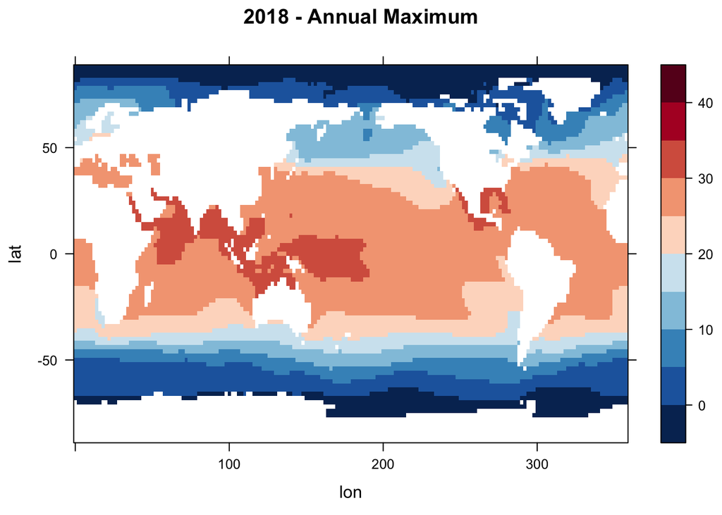

```r
# plot the annual maximum temperature for 2018
levelplot(sst_max_array ~ lon * lat, data=grid, at=cutpts, cuts=11, main=paste(nc_year, "Annual Maximum", sep=" - ") ,pretty=T, col.regions=(rev(brewer.pal(10,"RdBu"))))
```

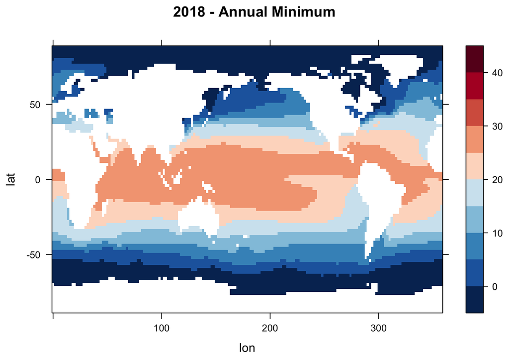

```r
# plot the annual minimum temperature for 2018
levelplot(sst_min_array ~ lon * lat, data=grid, at=cutpts, cuts=11, main=paste(nc_year, "Annual Minimum", sep=" - "), pretty=T, col.regions=(rev(brewer.pal(10,"RdBu"))))
```

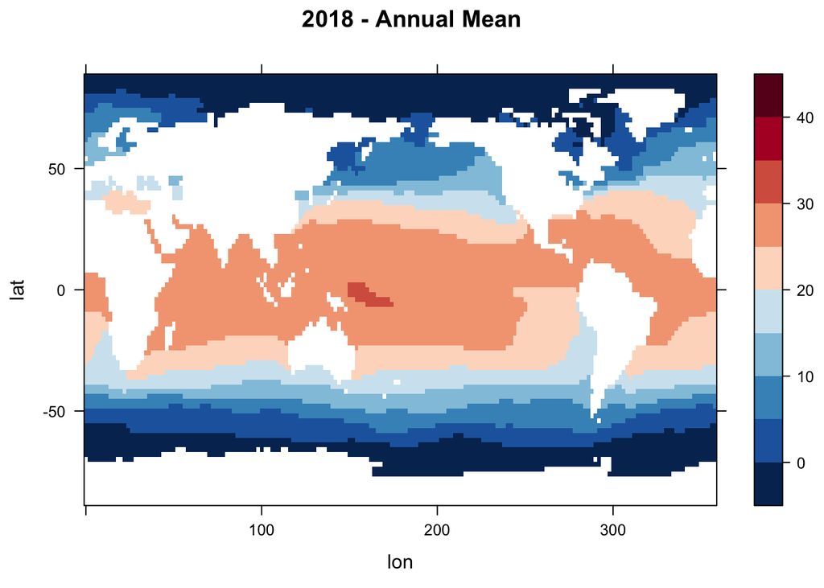

```r
# plat the annual mean temperature for 2018
levelplot(sst_mean_array ~ lon * lat, data=grid, at=cutpts, cuts=11, main=paste(nc_year, "Annual Mean", sep=" - "), pretty=T, col.regions=(rev(brewer.pal(10,"RdBu"))))
```

```r
# load the packages
library(ncdf4)
library(lattice)
library(RColorBrewer)

# setup the variables
# ncpath redacted for security
ncname_prefix <- "ersst.v5."
nc_year = "1900"
nc_name_extension = ".nc"
dname <- "sst"
nyears <- 100
nt <- 12
last_year <- nc_year
months <- c("January", "February", "March", "April", "May", "June", "July", "August", "September", "October", "November", "December")

# construct the surface temperature array
for (year in sprintf("%d", seq(nc_year,as.numeric(nc_year) + (nyears - 1)))) {
  for (month in seq(1:12)) {
    # construct the filename
    ncfname <- paste(ncpath, ncname_prefix, year, sprintf("%02d", month), nc_name_extension, sep="")

    # open the file
    ncin <- nc_open(ncfname)

    if (year == nc_year && month == 1) {
      # construct some globals the first time through the loop
      lon <- ncvar_get(ncin,"lon")
      lat <- ncvar_get(ncin,"lat")
      nlon <- dim(lon)
      nlat <- dim(lat)
      sst_array = array(dim=c(nlon, nlat, nyears*nt))
      }

    # get surface temperature for month
    sst_slice <- ncvar_get(ncin,dname)
    fillvalue <- ncatt_get(ncin,dname,"_FillValue")

    # replace netCDF fill values with NA's
    sst_slice[sst_slice==fillvalue$value] <- NA

    # save it to the global array
    sst_array[,,((as.numeric(year) - as.numeric(nc_year))*nt + month)] = sst_slice

    # save the last year that was run
    last_year = year

    # close file
    nc_close(ncin)
  }
}
# prepare to compute the annual min, max, and mean
# reshape the array into vector
sst_vec_long <- as.vector(sst_array)

# reshape the vector into a matrix
sst_mat <- matrix(sst_vec_long, nrow=nlon*nlat, ncol=nyears*nt)

# create a dataframe
lonlat <- as.matrix(expand.grid(lon,lat))
sst_df <- data.frame(cbind(lonlat,sst_mat))

# get the annual mean and max and min for 1900-1949
sst_df$max1 <- apply(sst_df[3:nyears/2*nt+2],1,max) # max
sst_df$min1 <- apply(sst_df[3:nyears/2*nt+2],1,min) # min
sst_df$mean1 <- apply(sst_df[3:nyears/2*nt+2],1,mean) # annual (i.e. row) means

# get the annual mean and max and min for 1950-1999
sst_df$max2 <- apply(sst_df[(nyears/2*nt+3):(nyears*nt + 2)],1,max) # max
sst_df$min2 <- apply(sst_df[(nyears/2*nt+3):(nyears*nt + 2)],1,min) # min
sst_df$mean2 <- apply(sst_df[(nyears/2*nt+3):(nyears*nt + 2)],1,mean) # annual (i.e. row) means

# convert the mean, max, min to arrays for plotting: 1900-1949
sst_max_array1 <- array(sst_df$max1, dim=c(nlon,nlat))
sst_min_array1 <- array(sst_df$min1, dim=c(nlon,nlat))
sst_mean_array1 <- array(sst_df$mean1, dim=c(nlon,nlat))

# convert the mean, max, min to arrays for plotting: 1950-1999
sst_max_array2 <- array(sst_df$max2, dim=c(nlon,nlat))
sst_min_array2 <- array(sst_df$min2, dim=c(nlon,nlat))
sst_mean_array2 <- array(sst_df$mean2, dim=c(nlon,nlat))

# plot the arrays
grid <- expand.grid(lon=lon, lat=lat)

cutpts <- c(-5,0,5,10,15,20,25,30,35,40,45)
```

The following six plots display the minimum, maximum, and mean sea surface temperatures for two time periods: 1900-1949 and 1950-1999.

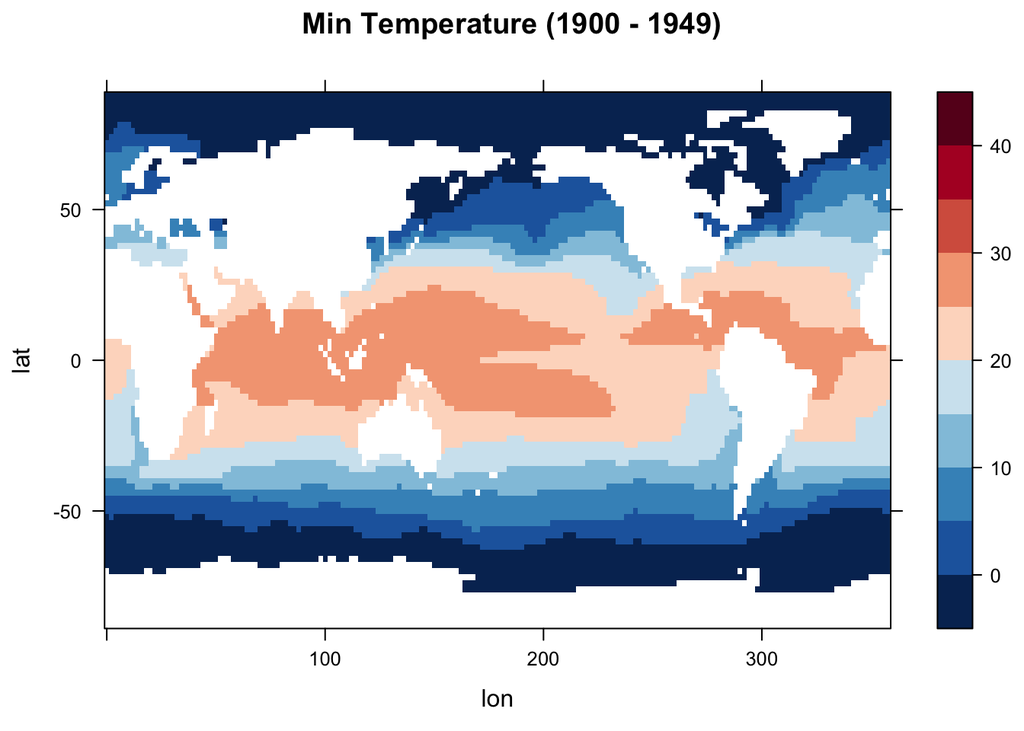

```r
# plot the pairs (1900-1949 and 1950-1999) min temp, max temp, and mean temp for all months
levelplot(sst_min_array1 ~ lon * lat, data=grid, at=cutpts, cuts=11, main=paste("Min Temperature (", nc_year, " - ", as.numeric(nc_year) + (nyears/2) - 1, ")", sep=""), pretty=T, col.regions=(rev(brewer.pal(10,"RdBu"))))
```

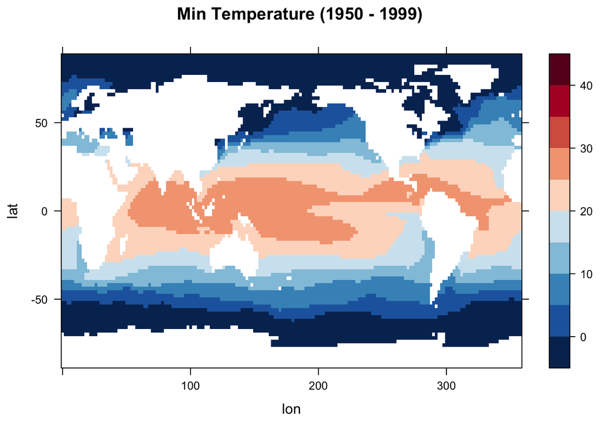

```r
levelplot(sst_min_array2 ~ lon * lat, data=grid, at=cutpts, cuts=11, main=paste("Min Temperature (", as.numeric(nc_year) + (nyears/2), " - ", as.numeric(nc_year) + (nyears - 1), ")", sep=""), pretty=T, col.regions=(rev(brewer.pal(10,"RdBu"))))
```

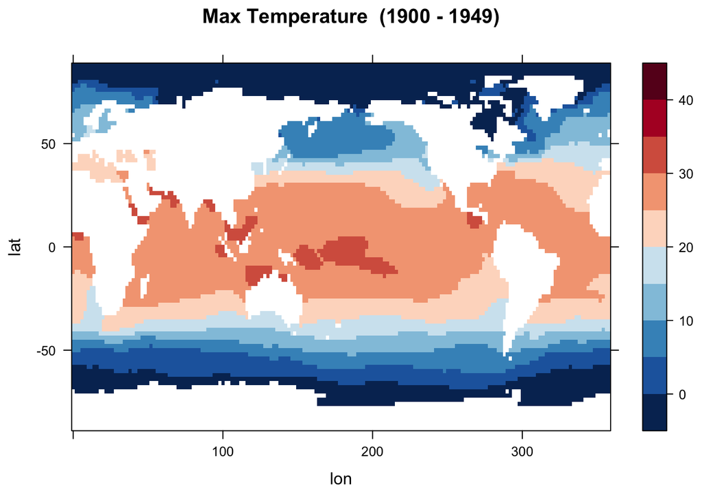

```r
levelplot(sst_max_array1 ~ lon * lat, data=grid, at=cutpts, cuts=11, main=paste("Max Temperature  (",  nc_year, " - ", as.numeric(nc_year) + (nyears/2) - 1, ")", sep=""), pretty=T, col.regions=(rev(brewer.pal(10,"RdBu"))))
```

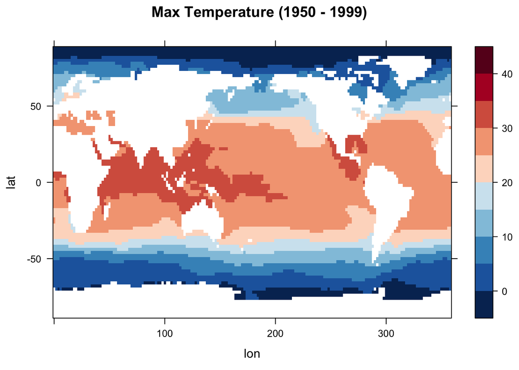

```r
levelplot(sst_max_array2 ~ lon * lat, data=grid, at=cutpts, cuts=11, main=paste("Max Temperature (", as.numeric(nc_year) + (nyears/2), " - ", as.numeric(nc_year) + (nyears - 1), ")", sep=""), pretty=T, col.regions=(rev(brewer.pal(10,"RdBu"))))
```

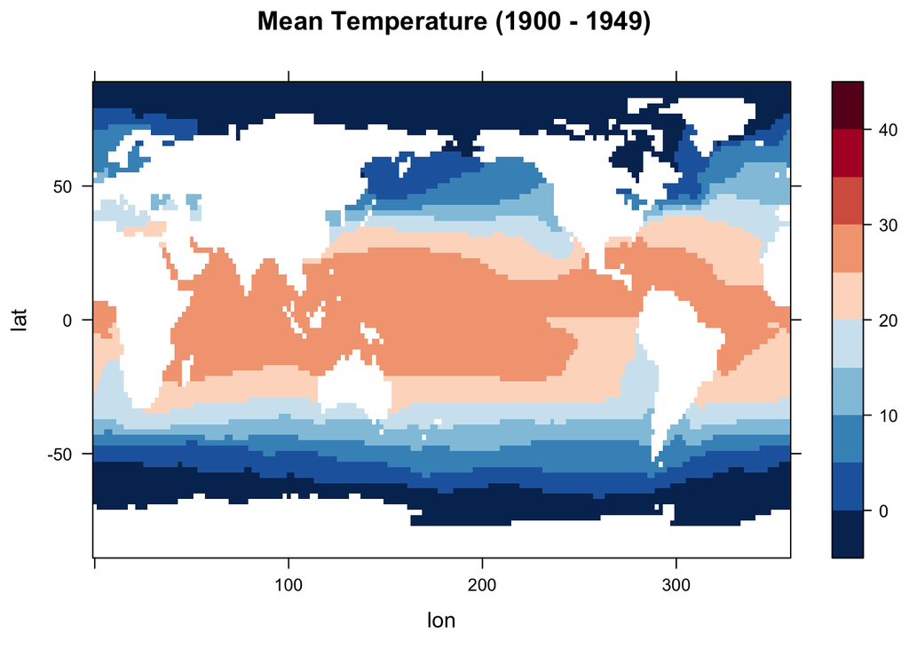

```r
levelplot(sst_mean_array1 ~ lon * lat, data=grid, at=cutpts, cuts=11, main=paste("Mean Temperature (", nc_year, " - ", as.numeric(nc_year) + (nyears/2) - 1, ")", sep=""), pretty=T, col.regions=(rev(brewer.pal(10,"RdBu"))))
```

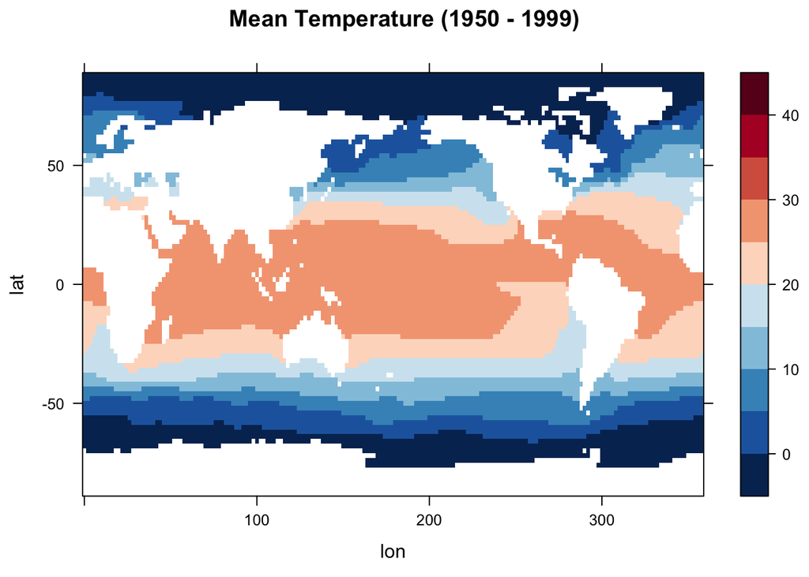

```r
levelplot(sst_mean_array2 ~ lon * lat, data=grid, at=cutpts, cuts=11, main=paste("Mean Temperature (", as.numeric(nc_year) + (nyears/2), " - ", as.numeric(nc_year) + (nyears - 1), ")", sep=""), pretty=T, col.regions=(rev(brewer.pal(10,"RdBu"))))
```